# Programming Assignment ML

Jordi Overeem

22 juni 2018

# Practical Machine Learning assignment

## Introduction

Using devices such as Jawbone Up, Nike FuelBand, and Fitbit it is now possible to collect a large amount of data about personal activity relatively inexpensively. These type of devices are part of the quantified self movement – a group of enthusiasts who take measurements about themselves regularly to improve their health, to find patterns in their behavior, or because they are tech geeks. One thing that people regularly do is quantify how much of a particular activity they do, but they rarely quantify how well they do it. In this project, your goal will be to use data from accelerometers on the belt, forearm, arm, and dumbell of 6 participants. They were asked to perform barbell lifts correctly and incorrectly in 5 different ways. More information is available from the website here: http://web.archive.org/web/20161224072740/http:/groupware.les.inf.puc-rio.br/har (see the section on the Weight Lifting Exercise Dataset).

## Data

The training data for this project are available here:

https://d396qusza40orc.cloudfront.net/predmachlearn/pml-training.csv

The test data are available here:

https://d396qusza40orc.cloudfront.net/predmachlearn/pml-testing.csv

The data for this project come from this source: http://web.archive.org/web/20161224072740/http:/groupware.les.inf.puc-rio.br/har. If you use the document you create for this class for any purpose please cite them as they have been very generous in allowing their data to be used for this kind of assignment.

## Loading packages and the data

```r
# SETTINGS & LIBRARIES
setwd("C:/Users/joov2/Desktop")
set.seed(555)
library(caret)
library(randomForest)
library(rattle)
```

```r
library(corrplot)
library(rpart)

# LOAD DATAFRAMES
training_data_url <- "https://d396qusza40orc.cloudfront.net/predmachlearn/pml-training.csv"
test_data_url <- "https://d396qusza40orc.cloudfront.net/predmachlearn/pml-testing.csv"
train <- data.frame(read.csv(file=training_data_url))
test <- data.frame(read.csv(file=test_data_url))
dim(train)
```

```
## [1] 19622   160
```

```r
dim(test)
```

```
## [1]  20 160
```

## Cleaning and pre-processing the data

With the code below, some ID variables and variables and cases with many missing values are removed from the dataset. Also, the data is partitioned and prepared for validation.

```r
# DATA CLEANSING
train <- train[,-c(1:6)] # Remove ID vars
test <- test[,-c(1:6)]

NZs <- nearZeroVar(train)
train <- train[, -NZs] # Remove vars with many missing values
test <- test[, -NZs]

NAs <- sapply(train, function(x) mean(is.na(x))) > 0.95
train <- train[, NAs == "FALSE"] # Remove cases with many NA's
test <- test[, NAs == "FALSE"]
dim(train)
```

```
## [1] 19622    54
```

```r
dim(test)
```

```
## [1] 20 54
```

```r
summary(train)
```

```
##    num_window      roll_belt        pitch_belt          yaw_belt
##  Min.   :  1.0   Min.   :-28.90   Min.   :-55.8000   Min.   :-180.00
##  1st Qu.:222.0   1st Qu.:  1.10   1st Qu.:  1.7600   1st Qu.: -88.30
##  Median :424.0   Median :113.00   Median :  5.2800   Median : -13.00
##  Mean   :430.6   Mean   : 64.41   Mean   :  0.3053   Mean   : -11.21
##  3rd Qu.:644.0   3rd Qu.:123.00   3rd Qu.: 14.9000   3rd Qu.:  12.90
##  Max.   :864.0   Max.   :162.00   Max.   : 60.3000   Max.   : 179.00
##  total_accel_belt  gyros_belt_x        gyros_belt_y       gyros_belt_z
##  Min.   : 0.00    Min.   :-1.040000   Min.   :-0.64000   Min.   :-1.4600
##  1st Qu.: 3.00    1st Qu.:-0.030000   1st Qu.: 0.00000   1st Qu.:-0.2000
##  Median :17.00    Median : 0.030000   Median : 0.02000   Median :-0.1000
##  Mean   :11.31    Mean   :-0.005592   Mean   : 0.03959   Mean   :-0.1305
##  3rd Qu.:18.00    3rd Qu.: 0.110000   3rd Qu.: 0.11000   3rd Qu.:-0.0200
##  Max.   :29.00    Max.   : 2.220000   Max.   : 0.64000   Max.   : 1.6200
##   accel_belt_x       accel_belt_y     accel_belt_z     magnet_belt_x
##  Min.   :-120.000   Min.   :-69.00   Min.   :-275.00   Min.   :-52.0
##  1st Qu.: -21.000   1st Qu.:  3.00   1st Qu.:-162.00   1st Qu.:  9.0
##  Median : -15.000   Median : 35.00   Median :-152.00   Median : 35.0
##  Mean   :  -5.595   Mean   : 30.15   Mean   : -72.59   Mean   : 55.6
##  3rd Qu.:  -5.000   3rd Qu.: 61.00   3rd Qu.:  27.00   3rd Qu.: 59.0
##  Max.   :  85.000   Max.   :164.00   Max.   : 105.00   Max.   :485.0
##  magnet_belt_y   magnet_belt_z       roll_arm         pitch_arm
##  Min.   :354.0   Min.   :-623.0   Min.   :-180.00   Min.   :-88.800
##  1st Qu.:581.0   1st Qu.:-375.0   1st Qu.: -31.77   1st Qu.:-25.900
##  Median :601.0   Median :-320.0   Median :   0.00   Median :  0.000
##  Mean   :593.7   Mean   :-345.5   Mean   :  17.83   Mean   : -4.612
##  3rd Qu.:610.0   3rd Qu.:-306.0   3rd Qu.:  77.30   3rd Qu.: 11.200
##  Max.   :673.0   Max.   : 293.0   Max.   : 180.00   Max.   : 88.500
##     yaw_arm          total_accel_arm  gyros_arm_x        gyros_arm_y
##  Min.   :-180.0000   Min.   : 1.00   Min.   :-6.37000   Min.   :-3.4400
##  1st Qu.: -43.1000   1st Qu.:17.00   1st Qu.:-1.33000   1st Qu.:-0.8000
##  Median :   0.0000   Median :27.00   Median : 0.08000   Median :-0.2400
##  Mean   :  -0.6188   Mean   :25.51   Mean   : 0.04277   Mean   :-0.2571
##  3rd Qu.:  45.8750   3rd Qu.:33.00   3rd Qu.: 1.57000   3rd Qu.: 0.1400
##  Max.   : 180.0000   Max.   :66.00   Max.   : 4.87000   Max.   : 2.8400
##   gyros_arm_z       accel_arm_x       accel_arm_y      accel_arm_z
##  Min.   :-2.3300   Min.   :-404.00   Min.   :-318.0   Min.   :-636.00
##  1st Qu.:-0.0700   1st Qu.:-242.00   1st Qu.: -54.0   1st Qu.:-143.00
##  Median : 0.2300   Median : -44.00   Median :  14.0   Median : -47.00
##  Mean   : 0.2695   Mean   : -60.24   Mean   :  32.6   Mean   : -71.25
```

[output cut: 50 more lines]

```
##  Max.   :311.00000   Max.   :231.0000   Max.   : 477.00   Max.   : 923.0
##  accel_forearm_z   magnet_forearm_x  magnet_forearm_y magnet_forearm_z
##  Min.   :-446.00   Min.   :-1280.0   Min.   :-896.0   Min.   :-973.0
##  1st Qu.:-182.00   1st Qu.: -616.0   1st Qu.:   2.0   1st Qu.: 191.0
##  Median : -39.00   Median : -378.0   Median : 591.0   Median : 511.0
##  Mean   : -55.29   Mean   : -312.6   Mean   : 380.1   Mean   : 393.6
##  3rd Qu.:  26.00   3rd Qu.:  -73.0   3rd Qu.: 737.0   3rd Qu.: 653.0
##  Max.   : 291.00   Max.   :  672.0   Max.   :1480.0   Max.   :1090.0
##  classe
##  A:5580
##  B:3797
##  C:3422
##  D:3216
##  E:3607
##
```

```r
head(train)
```

```
##   num_window roll_belt pitch_belt yaw_belt total_accel_belt gyros_belt_x
## 1         11      1.41       8.07    -94.4                3         0.00
## 2         11      1.41       8.07    -94.4                3         0.02
## 3         11      1.42       8.07    -94.4                3         0.00
## 4         12      1.48       8.05    -94.4                3         0.02
## 5         12      1.48       8.07    -94.4                3         0.02
## 6         12      1.45       8.06    -94.4                3         0.02
##   gyros_belt_y gyros_belt_z accel_belt_x accel_belt_y accel_belt_z
## 1         0.00        -0.02          -21            4           22
## 2         0.00        -0.02          -22            4           22
## 3         0.00        -0.02          -20            5           23
## 4         0.00        -0.03          -22            3           21
## 5         0.02        -0.02          -21            2           24
## 6         0.00        -0.02          -21            4           21
##   magnet_belt_x magnet_belt_y magnet_belt_z roll_arm pitch_arm yaw_arm
```

[output cut: 69 more lines]

```r
# DATA PREPARATION
in_train = createDataPartition(train$classe, p = 3/4, list = FALSE)
train <- train[in_train, ]
crossval <- train[-in_train, ]
```

## Model 1 - Decision Tree model

First a decision tree model is trained.

```r
# MODEL 1 | DECISION TREE
mdl1 <- train(classe~., data = train, method = "rpart") # Decision tree model

predict_train1 <- predict(mdl1, train)
confmtrx_train1 <- confusionMatrix(predict_train1, train$classe) # Confusion matrix on training data

print(confmtrx_train1)
```

```
## Confusion Matrix and Statistics
##
##           Reference
## Prediction    A    B    C    D    E
##          A 3806 1170 1206 1019  275
##          B   73  973   81  428  217
##          C  295  705 1280  855  559
##          D    0    0    0    0    0
##          E   11    0    0  110 1655
##
## Overall Statistics
##
##                Accuracy : 0.5241
##                  95% CI : (0.516, 0.5322)
##     No Information Rate : 0.2843
##     P-Value [Acc > NIR] : < 2.2e-16
##
##                   Kappa : 0.379
##  Mcnemar's Test P-Value : < 2.2e-16
##
## Statistics by Class:
##
##                      Class: A Class: B Class: C Class: D Class: E
## Sensitivity            0.9094  0.34164  0.49864   0.0000   0.6116
## Specificity            0.6516  0.93269  0.80133   1.0000   0.9899
## Pos Pred Value         0.5091  0.54910  0.34651      NaN   0.9319
## Neg Pred Value         0.9477  0.85517  0.88325   0.8361   0.9188
## Prevalence             0.2843  0.19350  0.17441   0.1639   0.1839
## Detection Rate         0.2586  0.06611  0.08697   0.0000   0.1124
## Detection Prevalence   0.5079  0.12040  0.25099   0.0000   0.1207
## Balanced Accuracy      0.7805  0.63717  0.64998   0.5000   0.8008
```

```r
predict_crossval1 <- predict(mdl1, crossval)
confmtrx_crossval1 <- confusionMatrix(predict_crossval1, crossval$classe) # Confusion matrix on cross validation data

print(confmtrx_crossval1)
```

```
## Confusion Matrix and Statistics
##
##           Reference
## Prediction   A   B   C   D   E
##          A 975 272 324 255  54
##          B  18 231  14 103  56
##          C  66 166 323 210 141
##          D   0   0   0   0   0
##          E   5   0   0  30 415
##
## Overall Statistics
##
##                Accuracy : 0.5314
##                  95% CI : (0.5151, 0.5477)
##     No Information Rate : 0.2909
##     P-Value [Acc > NIR] : < 2.2e-16
##
##                   Kappa : 0.3853
##  Mcnemar's Test P-Value : < 2.2e-16
##
## Statistics by Class:
##
##                      Class: A Class: B Class: C Class: D Class: E
## Sensitivity            0.9164  0.34529   0.4887   0.0000   0.6231
## Specificity            0.6511  0.93610   0.8055   1.0000   0.9883
## Pos Pred Value         0.5186  0.54739   0.3565      NaN   0.9222
## Neg Pred Value         0.9499  0.86465   0.8772   0.8365   0.9218
## Prevalence             0.2909  0.18289   0.1807   0.1635   0.1821
## Detection Rate         0.2665  0.06315   0.0883   0.0000   0.1134
## Detection Prevalence   0.5139  0.11536   0.2477   0.0000   0.1230
## Balanced Accuracy      0.7837  0.64070   0.6471   0.5000   0.8057
```

## Model 2 - Random Forest model

Second a random forest model is trained.

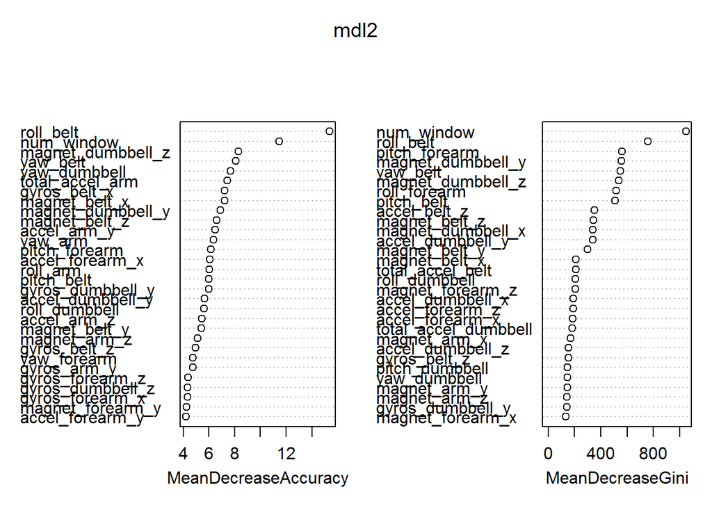

```r
# MODEL 2 | RANDOM FOREST
mdl2 <- randomForest(classe~., data = train, importance = TRUE, ntree = 10) # Random forest model
predict_train2 <- predict(mdl2, train)
confmtrx_train2 <- confusionMatrix(predict_train2, train$classe) # Confusion matrix on training data
varImpPlot(mdl2)
```

```r
print(confmtrx_train2)
```

```
## Confusion Matrix and Statistics
##
##           Reference
## Prediction    A    B    C    D    E
##          A 4185    0    0    0    0
##          B    0 2848    0    0    0
##          C    0    0 2567    1    0
##          D    0    0    0 2411    0
##          E    0    0    0    0 2706
##
## Overall Statistics
##
##                Accuracy : 0.9999
##                  95% CI : (0.9996, 1)
##     No Information Rate : 0.2843
##     P-Value [Acc > NIR] : < 2.2e-16
##
##                   Kappa : 0.9999
##  Mcnemar's Test P-Value : NA
##
## Statistics by Class:
##
##                      Class: A Class: B Class: C Class: D Class: E
## Sensitivity            1.0000   1.0000   1.0000   0.9996   1.0000
## Specificity            1.0000   1.0000   0.9999   1.0000   1.0000
## Pos Pred Value         1.0000   1.0000   0.9996   1.0000   1.0000
## Neg Pred Value         1.0000   1.0000   1.0000   0.9999   1.0000
## Prevalence             0.2843   0.1935   0.1744   0.1639   0.1839
## Detection Rate         0.2843   0.1935   0.1744   0.1638   0.1839
## Detection Prevalence   0.2843   0.1935   0.1745   0.1638   0.1839
## Balanced Accuracy      1.0000   1.0000   1.0000   0.9998   1.0000
```

```r
predict_crossval2 <- predict(mdl2, crossval)
confmtrx_crossval2 <- confusionMatrix(predict_crossval2, crossval$classe) # Confusion matrix on cross validation data

print(confmtrx_crossval2)
```

```
## Confusion Matrix and Statistics
##
##           Reference
## Prediction    A    B    C    D    E
##          A 1064    0    0    0    0
##          B    0  669    0    0    0
##          C    0    0  661    1    0
##          D    0    0    0  597    0
##          E    0    0    0    0  666
##
## Overall Statistics
##
##                Accuracy : 0.9997
##                  95% CI : (0.9985, 1)
##     No Information Rate : 0.2909
##     P-Value [Acc > NIR] : < 2.2e-16
##
##                   Kappa : 0.9997
##  Mcnemar's Test P-Value : NA
##
## Statistics by Class:
##
##                      Class: A Class: B Class: C Class: D Class: E
## Sensitivity            1.0000   1.0000   1.0000   0.9983   1.0000
## Specificity            1.0000   1.0000   0.9997   1.0000   1.0000
## Pos Pred Value         1.0000   1.0000   0.9985   1.0000   1.0000
## Neg Pred Value         1.0000   1.0000   1.0000   0.9997   1.0000
## Prevalence             0.2909   0.1829   0.1807   0.1635   0.1821
## Detection Rate         0.2909   0.1829   0.1807   0.1632   0.1821
## Detection Prevalence   0.2909   0.1829   0.1810   0.1632   0.1821
## Balanced Accuracy      1.0000   1.0000   0.9998   0.9992   1.0000
```

Accuracy of this model: 0.9997.

## Conclusion

Since the accuracy of the random forest model performs better than the decision tree model, the random forest model is used for predictions on the test data:

```r
predict <- predict(mdl2, test)
predict
```

```
##  1  2  3  4  5  6  7  8  9 10 11 12 13 14 15 16 17 18 19 20
##  B  A  B  A  A  E  D  B  A  A  B  C  B  A  E  E  A  B  B  B
## Levels: A B C D E
```